# Donor Profile: Republic of Korea

UNHCR Funding Analysis

Author

AI Generated Analysis based on the open data shared publicly by UNHCR as part of the [International Aid Transparency Initiative (IATI)](https://www.unhcr.org/iati-international-aid-transparency-initiative). Beware of data limitations and potential hallucinations! Thanks for reporting any [issues here](https://github.com/Edouard-Legoupil/iati/issues/new) – View all Reports

## Executive Summary

**Donor Profile: Republic of Korea**

Key challenges include a critical funding gap with 74% of required resources unmet across priority regions, reflecting pronounced inequities in allocation and program coverage. This gap notably undermines humanitarian response continuity in crisis hotspots such as Jordan, Lebanon, and Turkey, where limited funding coverage—averaging 14% with some as low as 1.4%—heightens vulnerability and operational risk. Further compounding this is a highly concentrated but volatile funding portfolio: large allocations exceeding $16 million coexist with median disbursements near $1.6 million, alongside a low transaction frequency of 39 annually, constraining funding predictability and scale-up potential.

For fundraisers, these findings suggest several strategic focus areas:

- **Target underfunded regions and project types** to close critical resource gaps and reduce funding volatility, thereby maximizing return on investment and program continuity.
- **Enhance transaction frequency alongside size**, encouraging Korea to increase the number of contributions to improve funding predictability and flexibility essential for agile crisis response.
- **Leverage Korea’s demonstrated growth and scale-up potential** by co-developing innovative resilience programs that emphasize accountability, measurable outcomes, and scalable solutions.
- **Cultivate mid-tier Korean donors and partnerships** to diversify funding streams, reducing overreliance on few large contributors and stabilizing long-term financial flows.
- **Prioritize flexible, earmarked funding arrangements** to optimize allocation efficiency, tailor regional responses, and reinforce strategic alliances.

In sum, the Republic of Korea represents a high-potential donor whose evolving commitment—if strategically mobilized—can act as a powerful catalyst for scalable humanitarian impact in emergency and resilience contexts. Immediate, focused engagement can unlock latent capacity, harmonize funding equity, and ensure sustained, measurable progress across diverse beneficiary regions.

## Ranking

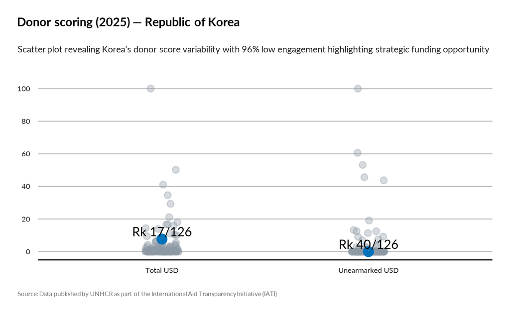

TRUE

## Focus Portfolio

The Republic of Korea portfolio exhibits significant funding concentration, with a maximum allocation reaching over $16.7 million while median funding sits near $1.6 million, signaling pronounced disparities in resource distribution. This concentration underscores critical opportunities to strategically leverage donor investments by targeting underfunded regions where impact multipliers remain untapped. Notably, nine UNHCR regions present varying funding levels, with funding gaps that, if addressed, could scale program reach and effectiveness substantially. Investing to balance this portfolio can optimize emergency response and resilience efforts by reducing funding volatility and reinforcing partnership engagement. We recommend prioritizing allocation towards underfunded segments identified in the project data, positioning donors as catalysts in transformative change. Mobilizing funds to close these disparities not only reinforces UNHCR’s accountability and innovation but also strategically mitigates risks related to uneven resource flow. Decision-makers should seize this pivotal moment to channel investments that harmonize funding equity, maximize operational impact, and fortify strategic alliances, ensuring that donor contributions translate into measurable outcomes across all beneficiary regions.

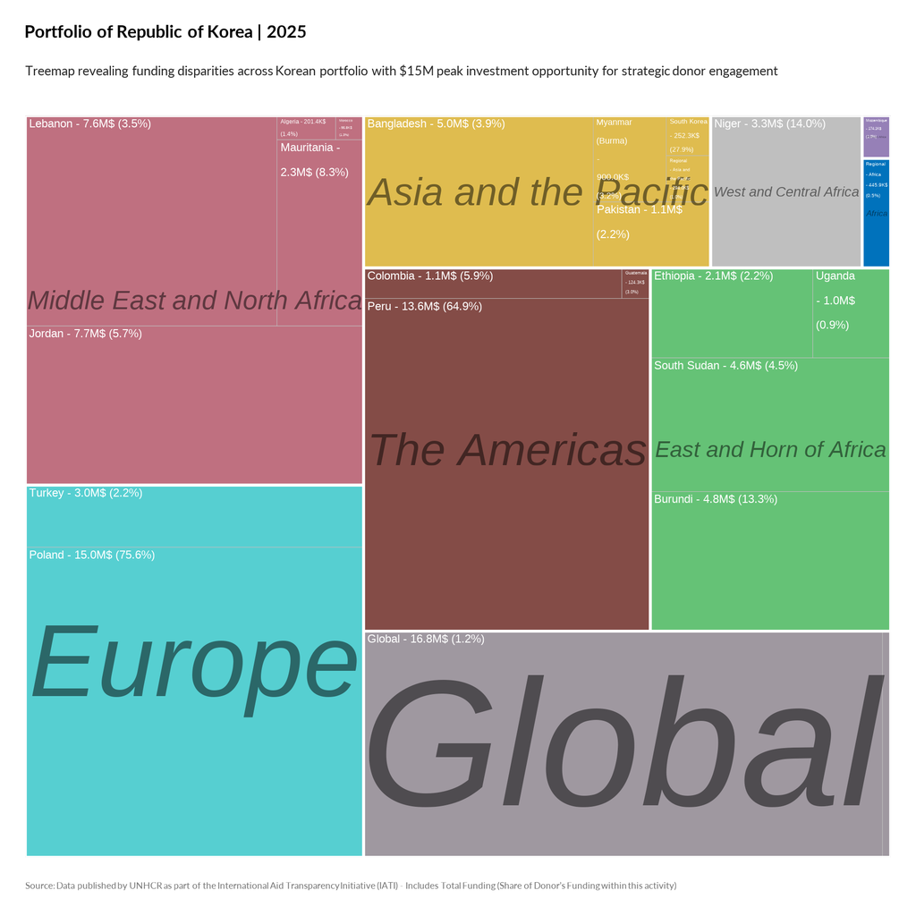

TRUE

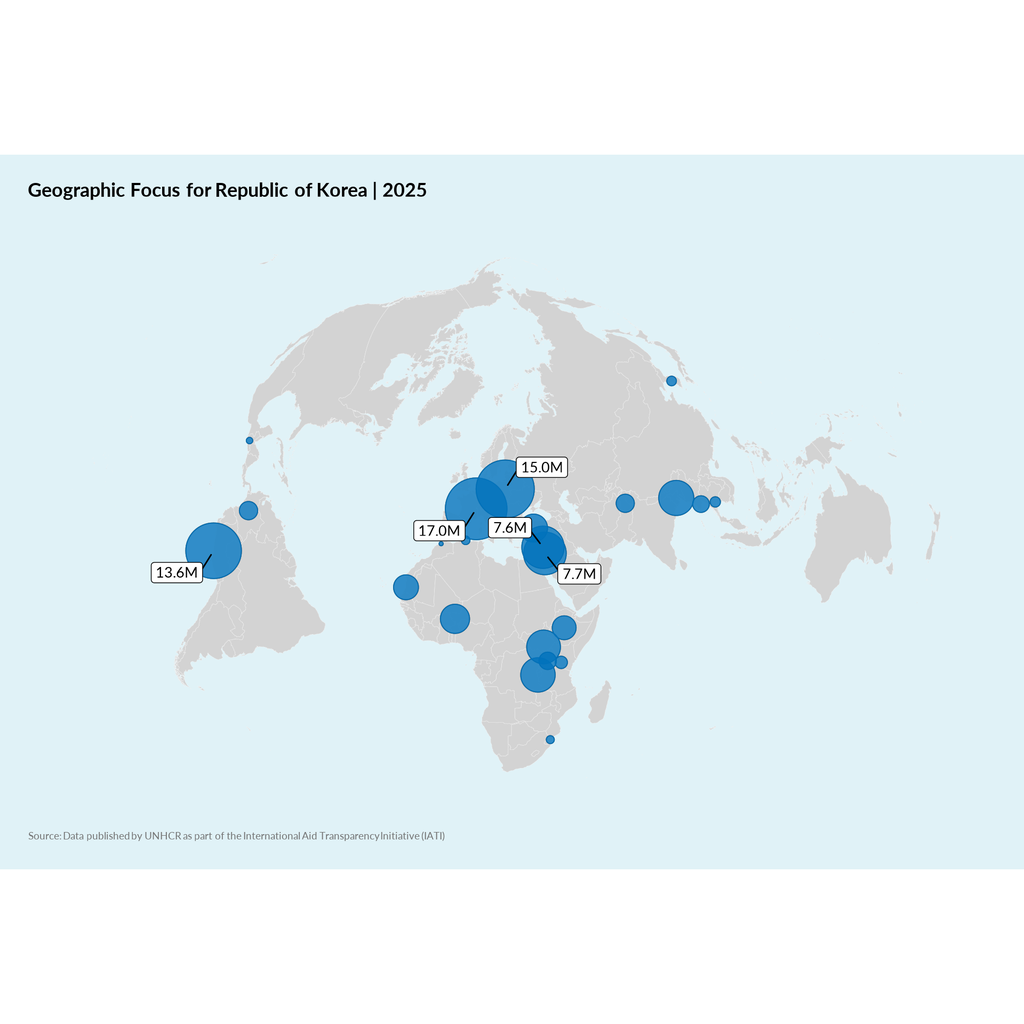

TRUE